# On The Edge

Martin Borkovec

2025-07-10

# Parsing

Let’s take a closer look at how to use `geom_edge_label()`.  
In most cases you hopefully won’t have to worry much about this geom, since the defaults should produce satisfying results.  
But if you do want to customize anything, it might get a bit tricky. Since splits of continuous variables contain intervals we want to be able to plot inequality signs. Using Unicode to do so, proved problematic among other things with some pdf engines. Therefore these signs are added as parsable text.  
However, this opens the door to some other potential problems. To ensure correct behaviour as per default `geom_edge_label()` parses only these signs. Therefore the additional argument `parse_all` has been added which allows to parse the whole label if set to `TRUE`. First let’s once more recreate the **WeatherPlay** tree. But this time we are going to arbitrarily change the first level of **outlook** to “beta”

```r
library(ggparty)
data("WeatherPlay", package = "partykit")
levels(WeatherPlay$outlook)[1] <- c("beta")
sp_o <- partysplit(1L, index = 1:3)
sp_h <- partysplit(3L, breaks = 75)
sp_w <- partysplit(4L, index = 1:2)
pn <- partynode(1L, split = sp_o, kids = list(
  partynode(2L, split = sp_h, kids = list(
    partynode(3L, info = "yes"),
    partynode(4L, info = "no"))),
  partynode(5L, info = "yes"),
  partynode(6L, split = sp_w, kids = list(
    partynode(7L, info = "yes"),
    partynode(8L, info = "no")))))
py <- party(pn, WeatherPlay)
```

## Default Mapping

As per default `geom_edge_label()` maps `label` to **plot_data**’s **breaks_label**.  
Plotting the tree in the usual way will lead to the following plot.

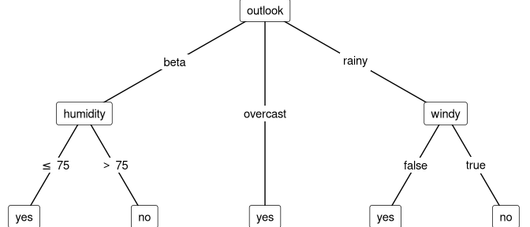

```r
ggparty(py) +
  geom_edge() +
  geom_edge_label() +
  geom_node_splitvar() +
  geom_node_info()
```

As we can see “beta”has not been parsed, even though the argument `parse` defaults to `TRUE` and the inequality signs have been parsed. This is due to the fact, that `geom_edge_label()` detects these signs, generated by `get_plot_data()` and deparses the rest of the label to prevent unintended parsing. In case we change the default mapping of `label` this is no longer true. By setting `parse` to `FALSE` we can plot the unparsed labels:

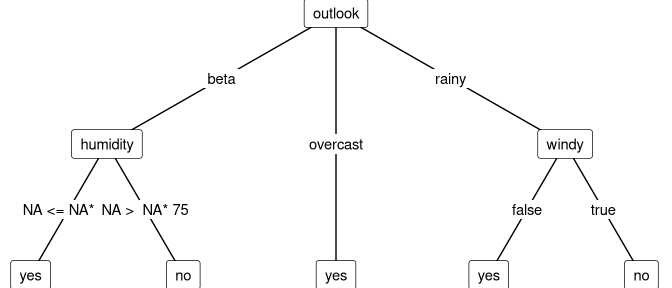

```r
ggparty(py) +
  geom_edge() +
  geom_edge_label(parse = FALSE) +
  geom_node_splitvar() +
  geom_node_info()
```

On the other hand, if we want to parse the beta which is now one of the splitvariables of **outlook**, we can set the additional argument `parse_all` to `TRUE`.

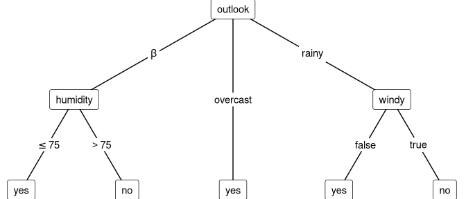

```r
ggparty(py) +
  geom_edge() +
  geom_edge_label(parse_all = TRUE) +
  geom_node_splitvar() +
  geom_node_info()
```

## Custom Mapping

If we change the mapping of `label`, `geom_edge_label()` will no longer automatically deparse any part of the label. Therefore the argument `parse_all` has no longer any effect and only `parse` determines the parsing behaviour.

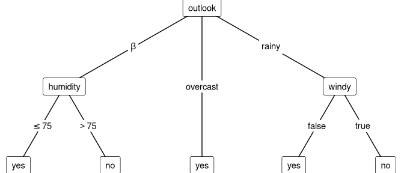

```r
ggparty(py) +
  geom_edge() +
  geom_edge_label(mapping = aes(label = paste(breaks_label)),
                  parse_all = FALSE #has no effect
                  ) +
  geom_node_splitvar() +
  geom_node_info()
```

Although the specified mapping doesn’t really change anything compared to the default, it makes it harder to prevent “beta” from being parsed, since now nothing gets automatically deparsed.  
So if we want to parse certain edges and not others, we need to call `geom_edge_label` multiple times.

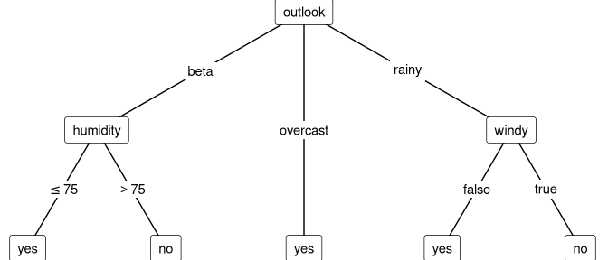

```r
ggparty(py) +
  geom_edge() +
  geom_edge_label(mapping = aes(label = paste(breaks_label)),
                  ids = 2,
                  parse = FALSE
                  ) +
  geom_edge_label(mapping = aes(label = paste(breaks_label)),
                  ids = -2,
                  parse = TRUE
                  ) +
  geom_node_splitvar() +
  geom_node_info()
```

These last two plots were just to illustrate the slightly changed mechanics when setting a mapping for `label`. Let’s now take a look at an example of how to add superscripts to the edge labels. Using the syntax of [plotmath](https://stat.ethz.ch/R-manual/R-devel/library/grDevices/html/plotmath.html) we can parse math notations and special characters. So to add a superscript we need to paste a `*` to tell `parse` to juxtapose the next symbol which is “NA”. “NA” doesn’t create any character, but is necessary as to add the superscript to it since we can not add it directly to the **breaks_label**.

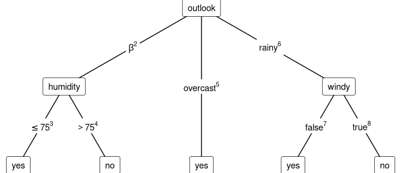

```r
ggparty(py) +
  geom_edge() +
  geom_edge_label(mapping = aes(label = paste(breaks_label, "*NA^", id))) +
  geom_node_splitvar() +
  geom_node_info()
```

If we paste anything that could be parsed but we don’t want it to be, we can deparse it by enclosing it within a pair of `\"`. Remember to add a `*` at the beginning and the end.

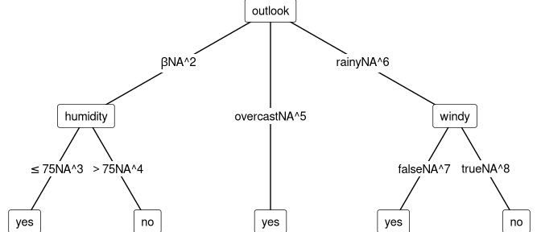

```r
ggparty(py) +
  geom_edge() +
  geom_edge_label(mapping = aes(label = paste0(breaks_label, "*\"NA^\"*", 1:8))) +
  geom_node_splitvar() +
  geom_node_info()
```

# Long breaks_label

In the presence of several levels for some splits we can use the argument `splitlevels` and plot the levels in several chunks, nudging them slightly in the right position. In some cases the `shift` argument may also come in handy, as it slides the label along the edge.

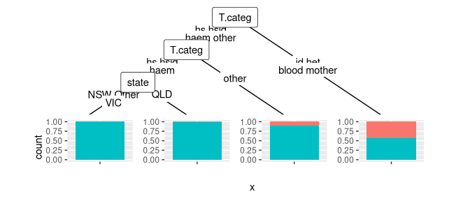

```r
library(MASS)
SexTest <- ctree(sex ~ ., data = Aids2)
ggparty(SexTest) +
  geom_edge() +
  geom_edge_label(splitlevels = 1:2, nudge_y = 0.025) +
  geom_edge_label(splitlevels = 3:4, nudge_y = -0.025) +
  geom_node_splitvar() +
  geom_node_plot(gglist = list(geom_bar(aes(x = "", fill = sex),
                                        position = position_fill())),
                 shared_axis_labels = TRUE)
```

Alternatively the argument `max_length`provides an option to easily truncate the names of the levels.

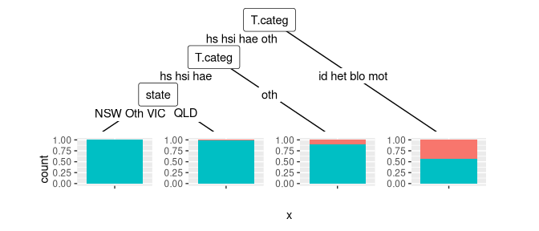

```r
library(MASS)
SexTest <- ctree(sex ~ ., data = Aids2)
ggparty(SexTest) +
  geom_edge() +
  geom_edge_label(max_length = 3) +
  geom_node_splitvar() +
  geom_node_plot(gglist = list(geom_bar(aes(x = "", fill = sex),
                                        position = position_fill())),
                 shared_axis_labels = TRUE)
```